# Homework 6 - Naiara Alonso Montes

## Exercises 1 & 2

*Experiment with k-ary (d-ary) heaps on random integers from 0 to 999 999 999 (precision 1B or 1 000 000 000). Experiment with k= 2..12. (for k=2 use the same implementation starting from index 0, not the “standard” binary heap starting from 1).*

A k-ary is a binary heap but instead of 2 child nodes, it has $k$ child nodes. The results obtained after running the code is the following:

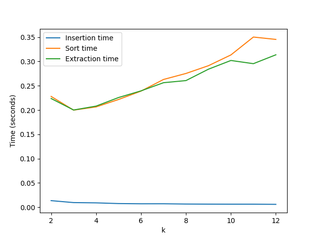

Apparently, the sorting and extraction take the same time, but according to time-complexities:

- Insertion: $O(\log_{k}(n))$
- Sorting: $O(k⋅n\log_{k}(n)$
- Extraction: $O(k\log_{k}(n))$

If I increase the value of $k$ and plot it...

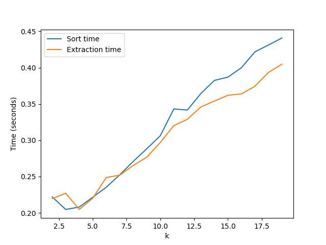

*Build heap (heapify) unsorted random data with linear time method. Report heapify times for 1000 and 1000 000 values, and how much slower it got by 1000-fold increase of data.*

If we consider that the base case for fold of 1000 elements, the measured time is 0.01, I can create a generalistic formula that can approaches the results for any number of elements $x$.

$$f(x) ≈ \frac{x}{1000}⋅0.01$$

$$f(1000000) ≈ \frac{1000000}{1000}⋅0.01 ≈ 10$$

This plot shows the real-life output(over my PC):

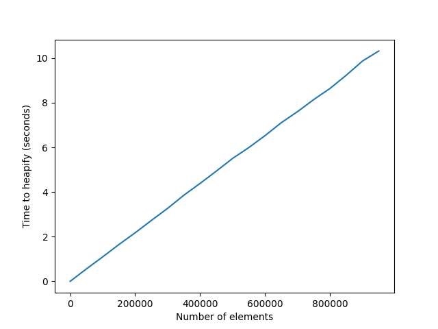

**IMPORTANT**: as the 1000-fold was taking too much time, the plot is created using a 50000-fold instead.

The trendiness is linear and the expected output matches the real life output.

*Compare linear heapify time vs simply inserting values one by one. Note that this can be done in-place within the same array, simply taking the next element (insertion) and using bubble-up. Report similar time measurements. State which method is actually faster, by how much (on 1M values).*

Same as in previous exercise, the measured time for bubble-up in 1000-fold is 0.0026. We can again create a formula:

$$f(x) ≈ \frac{x}{1000}⋅0.0026$$

For 1 million elements:

$$f(1000000) ≈ \frac{1000000}{1000}⋅0.0026 ≈ 2.6$$

Now the plot:

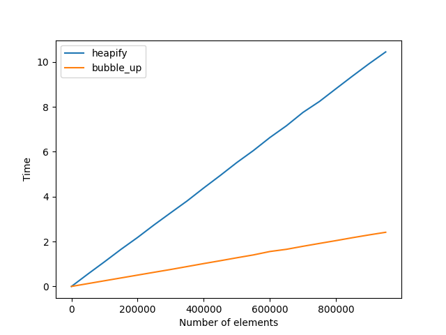

**IMPORTANT**: as the 1000-fold was taking too much time, the plot is created using a 50000-fold instead.

As theoretical values match again with real-life values, I can affirm that bubble-up method is $\frac{0.01}{0.0026} ≈ 3.85$ times faster.

*Apply random decrease-value to a randomly selected element of each heap (random position) by random integer decrease in between 1 to 100. Report the times and how much slower it becomes when 1000-fold increasing data. Assess, which k demonstrates best performance in each measurement.*

I will present the results in two plots and then I'll explain the results:

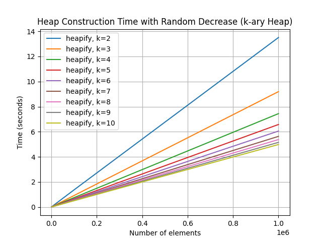

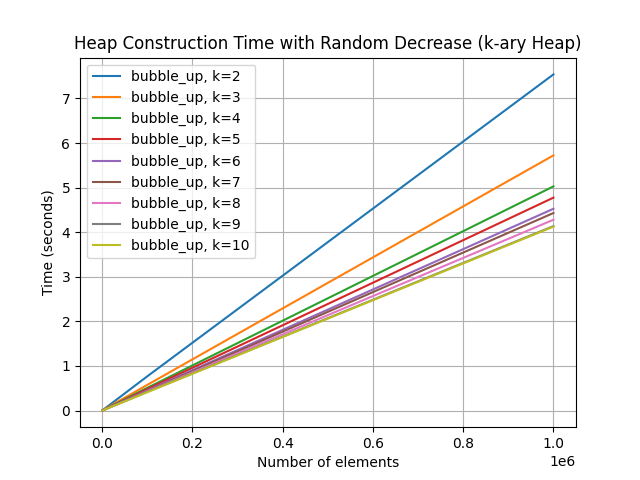

- The random change in a single values affects both heapify and bubble-up implementations
- After trying with many different values of $k$, as it is seen in the plot, the highest, the better. Despite the fact that a higer $k$ performs better, increasing it to a exagerate value (for example 1000) will not provide much difference in terms of performance compare to a $k = 10$. I will suggest to choose a value of $k$ that is coherent to the number of values in the heap.

*After identifying the best k, report the values of root and its children (top two layers) on the same data, i.e. heapify, one by one insertions, and random-decrease operations.*

```
After heapify: Root: 926315, Left Child: 909230, Right Child: 710591
After one-by-one insertions (bubble-up): Root: 946389, Left Child: 763645, Right Child: 901550
After random decrease: Root: 946389, Left Child: 704624, Right Child: 901550
```

## Exercise 3

*Analyze a continuous stream of integers identifying the smallest k elements in stream (continuously). Rreport at the end of processing the stream the k’th smallest value in the Strong data. Perform the experiments, report the identified value and the time it took to run the algorithm.*

According to the exercise description, there was no way to use only 5 columns and 18 rows to try all combinations, so I used the distibution seen in **[this Excel](https://tartuulikool-my.sharepoint.com/:x:/g/personal/naiara_ut_ee/EV9kiFmYEqlMvH0JlelHGDABxyjk6ZV4sQY_gz_oqpzBTA?e=FN4TfD)** (all time info, kth smallest... is there).

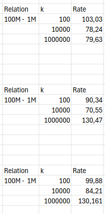

This is the rate relation between times for Fibonacci with module (1000, 1000000, 1000000000).

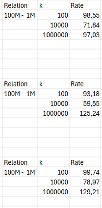

An this is the same but for random values.

Despite the fact that random values are "random" and can vary a lot, by applying the module what we get is that processing time for both randomness strategy is similar.

## Exercise 4

*Succinct tree representation (heap-like). Let’s create a succinct heap-like representation of a BST made for Collatz Sequence starting from 17, inserted “as is” into a BST (no balancing). See HW4, EX1. And secondly, let’s do a traversal of that tree based on succinct representation only.*

*Create the heap-like representation of that tree - the bit-vector (feel free to use a list of bytes/integers instead of bits for this learning exercise) and list of tree nodes. You may want to create new leaf nodes (to be labeled by 0), where leaves are not present in the beginning.*

*Using the two linear lists a)succinct bit-vector representation and b) the respective values stored in a list/array, make a breadth-first traversal of the tree. Output tree node values; and where the value does not exist, the “L” (leaf).*

*Note, that you would need to implement simple rank functions (at which index m is the k’th 1; count the k (#1-s) of how many 1-s there is until position m). As the example data is so small, let’s not worry about the most optimal storage of the bit-vector or the complexity of these assisting functions (simple linear counting is sufficient). Goal is to simply get it running.*

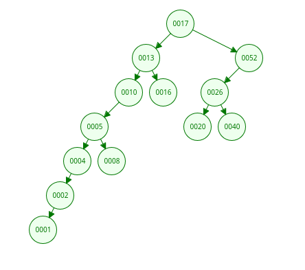

This is the visual representation of the BST.

The bit-vector representation is:

```
[1, 1, 1, 1, 1, 1, 1, 0, 0, 0, 0, 1, 0, 0, 0, 1, 0, 0, 1, 1, 1, 0, 0, 1, 0, 0, 0]
```

This is the pseudo code to get it:

```python
for all nodes in tree starting with root:
  go left
  if I have left child, add 1 and go left, recursive call
  else add 0
  if I have right child, add 1 and go right, recursive call
  else add 0

  if I have no childs, go back a level
```

[output not shown]

With L indicating that that nodes do not have any/some child.

## Exercise 5

*Let’s now create a succinct depth first parenthesisation based representation for a more general tree, the trie of words. Implement the “size of subtree” function using the similar principle as in the EX4 task.*

*First, build the parenthesis- based succinct depth-first representation for the TRIE (output the parentheses (we know they can also be implemented with 1 and 0, but for sake of clarity, let’s use parentheses). Below the opening parentheses print the letters in respective node. Second, perform the traversal and one “size of subtree” operation. Use first the smaller data, and node “ab” as the query. And only when that works, test it for larger list of words.*

```
words = ["abab", "abacus", "taco", "tactic", "aba" ]
words = ["action", "activate", "actor", "active", "activity", "actual", "actress", "actionable", "activist", "actuate", "act", "acting", "activator", "actuation", "actively", "actin", "actinium", "actinoid", "actinosphere", "actomyosin"]
```

```
((((aba(abab)(((abacus))))))((((taco)(((tactic)))))))
Size of the subtree rooted at 'ab': 6
```

```
((((act(((action((((actionable))))))((((activate)((activator))))(active((actively)))(((activity))((activist))))(actin(acting)(((actinium)))(((actinoid))((((((actinosphere)))))))))((actor)((((((actomyosin)))))))(((actual)((actuate)(((actuation))))))((((actress))))))))
Node 'ab' not found.
```

Instead of writting the letter for each parenthesis, it group all letters until a division is needed.

## Exercise 6 (bonus)

The main point in the article, divides in two:

- Consider the impact of Virtual Memory over well-known algorithms.
- Perform the time measurements over real machines with some kind of stress over the memory to appreciate the real impacts.

My opinion over this article is that there will be implementations over standarized "algorithms" as there were implementations and new better-performance algorithms in the past, but the key point is that this algorithms are usually formulated by mathematicians who could/could not have knowledge of CS. To considere if and algorithm is "optimal" it must be tested over all possible application fields, as it might not perform equally in all.

```python
!jupyter nbconvert --to html HW6.ipynb
```